# Homework 7

### Author: Daniel McNeela

## Problem 1

```python
import numpy as np
import matplotlib.pyplot as plt

from scipy.io import loadmat

%matplotlib inline
```

```python
data = loadmat('data/mnist_data/images.mat')
X = data['images']
```

Here I implement Lloyd's algorithm...

```python
def lloyds(X, K):
    # Create a dictionary to hold the clusters
    cluster_nums = [j for j in range(K)]
    clusters = dict((j, []) for j in cluster_nums)
    means = dict((j, 0) for j in cluster_nums)
    # Assign random initial clusters
    for i in range(X.shape[2]):
        rand_cluster = np.random.randint(K)
        clusters[rand_cluster].append(X[:, :, i])
    # Begin algorithm
    iteration = 0
    while True:
        for k in clusters:
            mean = np.zeros((28, 28))
            for point in clusters[k]:
                mean += point
            mean *= 1 / len(clusters[k])
            means[k] = mean
        new_clusts = dict((j, []) for j in cluster_nums)
        for i in range(X.shape[2]):
            k = compute_MSE(X[:, :, i], means)
            new_clusts[k].append(X[:, :, i])
        truth_vals = [np.array_equal(clusters[k], new_clusts[k]) for k in clusters]
        if not False in truth_vals:
            return clusters, means
        clusters = new_clusts
        iteration += 1

def compute_MSE(X, means):
    min_diff = (0, (X - means[0]) @ (X - means[0]))
    for m in means:
        diff = (m, (X - means[m]) @ (X - means[m]))
        if np.linalg.norm(diff[1]) < np.linalg.norm(min_diff[1]):
            min_diff = diff
    return min_diff[0]
```

Now I run Lloyd's for $k = 5, 10, 20$ and visualize the cluster centers. For $k = 10$ we more or less have a different digit for each cluster. Each digit clusters with itself. With $k = 5$ we only have half as many representatives, so we get clusters consisting of mainly two digits. For $k = 20$, we have roughly two clusters for each digit, so each image is placed in one of those two clusters based on whichever image it resembles most closely.

```python
clusters5, means5 = lloyds(X, 5)
```

```
Ceter for cluster 0
Ceter for cluster 1
Ceter for cluster 2
Ceter for cluster 3
Ceter for cluster 4
```

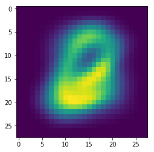

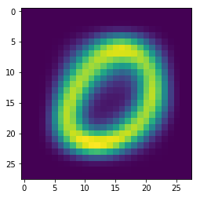

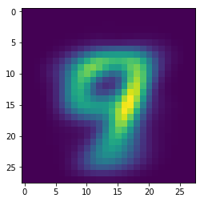

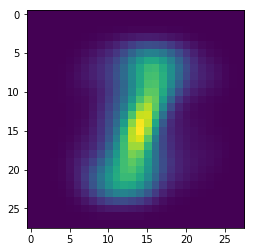

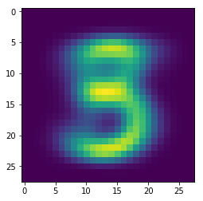

```python
for center in means5:
    print("Ceter for cluster %d" % center)
    plt.figure()
    plt.imshow(means5[center])
```

```python
clusters10, means10 = lloyds(X, 10)
```

```
Center for cluster 0
Center for cluster 1
Center for cluster 2
Center for cluster 3
Center for cluster 4
Center for cluster 5
Center for cluster 6
Center for cluster 7
Center for cluster 8
Center for cluster 9
```

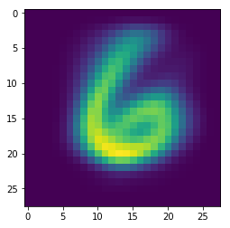

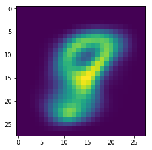

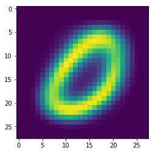

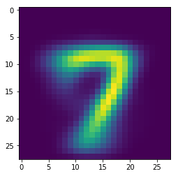

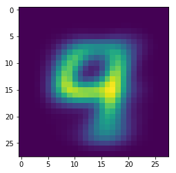

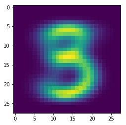

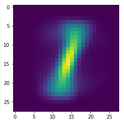

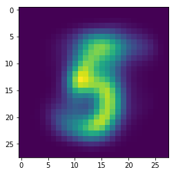

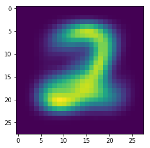

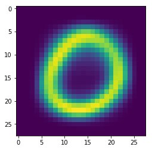

```python
for center in means10:
    print("Center for cluster %d" % center)
    plt.figure()
    plt.imshow(means10[center])
```

```python
clusters20, means20 = lloyds(X, 20)
```

```
Center for cluster 0
Center for cluster 1
Center for cluster 2
Center for cluster 3
Center for cluster 4
Center for cluster 5
Center for cluster 6
Center for cluster 7
Center for cluster 8
Center for cluster 9
Center for cluster 10
Center for cluster 11
Center for cluster 12
Center for cluster 13
Center for cluster 14
Center for cluster 15
Center for cluster 16
Center for cluster 17
Center for cluster 18
Center for cluster 19
```

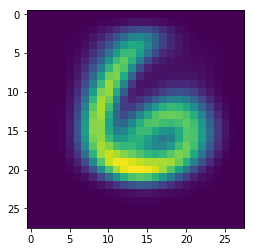

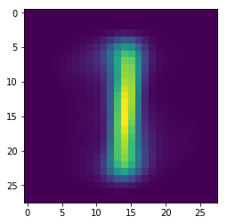

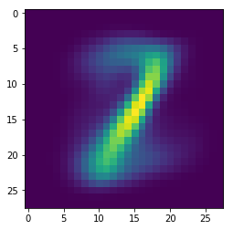

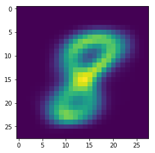

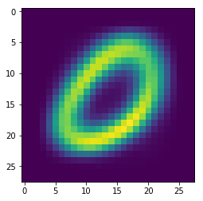

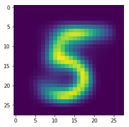

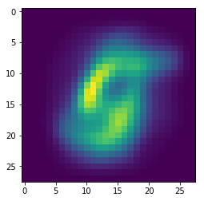

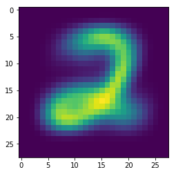

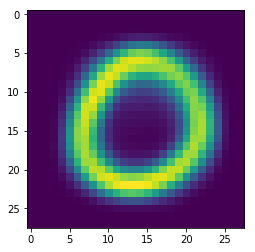

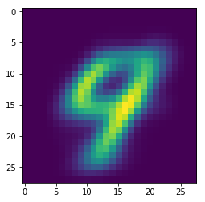

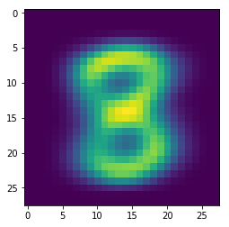

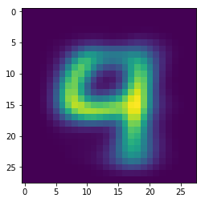

[8 more figures not shown]

```python
for center in means20:
    print("Center for cluster %d" % center)
    plt.figure()
    plt.imshow(means20[center])
```

## Problem 2

```python
from scipy.misc import imread
from sklearn.decomposition import TruncatedSVD
```

```python
face = imread('data/low-rank_data/face.jpg')
```

Here is the original face.

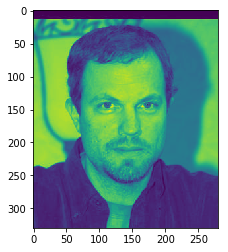

```python
plt.imshow(face);
```

Here is the rank-5 approximation.

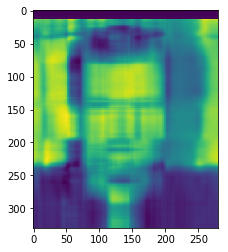

```python
U, s, V = np.linalg.svd(face)
s[5:] = 0
S = np.zeros((330, 280))
S[:280, :280] = np.diag(s)
face5 = U @ S @ V
plt.imshow(face5);
```

Here is the rank-20 approximation.

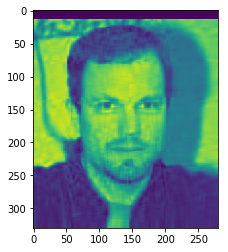

```python
U, s, V = np.linalg.svd(face)
s[20:] = 0
S = np.zeros((330, 280))
S[:280, :280] = np.diag(s)
face20 = U @ S @ V
plt.imshow(face20);
```

And here is the rank-100 approximation.

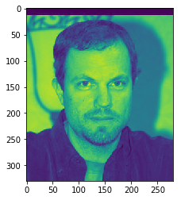

```python
U, s, V = np.linalg.svd(face)
s[100:] = 0
S = np.zeros((330, 280))
S[:280, :280] = np.diag(s)
face100 = U @ S @ V
plt.imshow(face100);
```

Now I plot the mean squared error for the rank-i approximation, where i ranges from 1 to 100.

```python
def plotMSE(face, num_approx):
    fig = plt.figure()
    ax = fig.add_subplot(111)
    mses = []
    xs = [i for i in range(num_approx)]
    for i in range(num_approx):
        mses.append(MSE(face, i))
    ax.plot(xs, mses, 'b-')

def MSE(face, k):
    U, s, V = np.linalg.svd(face)
    s[k:] = 0
    S = np.zeros((330, 280))
    S[:280, :280] = np.diag(s)
    facek = U @ S @ V
    mse = np.linalg.norm(face - facek)
    return mse
```

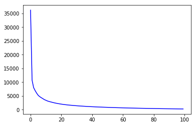

```python
plotMSE(face, 100)
```

Now, I compute the same rank approximations for the sky photo.

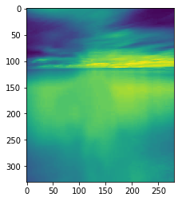

```python
img = imread('data/low-rank_data/sky.jpg')
plt.imshow(img);
```

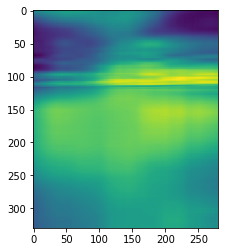

```python
U, s, V = np.linalg.svd(img)
s[5:] = 0
S = np.zeros((330, 280))
S[:280, :280] = np.diag(s)
img5 = U @ S @ V
plt.imshow(img5);
```

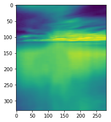

```python
U, s, V = np.linalg.svd(img)
s[20:] = 0
S = np.zeros((330, 280))
S[:280, :280] = np.diag(s)
img20 = U @ S @ V
plt.imshow(img20);
```

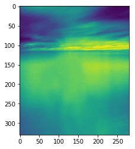

```python
U, s, V = np.linalg.svd(img)
s[100:] = 0
S = np.zeros((330, 280))
S[:280, :280] = np.diag(s)
img100 = U @ S @ V
plt.imshow(img100);
```

I am unable to differentiate the rank-20 sky photo from the original, whereas with the face I need to get to the rank-100 approximation in order to not be able to differentiate it from the original. This is probably because in the sky photo, the colors run together and the level of detail is significantly less than for the face photo.

## Problem 3

```python
# Load in joke data
joke_data = loadmat('data/joke_data/joke_train.mat')

# Replace NaNs with 0
normalized_data = np.nan_to_num(joke_data['train'])
```

Here I compute the user and joke representations $U'$ and $V'$ in the following way. Let $U \Sigma V^T$ be the SVD of the data matrix. Then we have

$$U' = U \Sigma^{1/2}$$$$V' = \Sigma^{1/2} V^T$$

```python
# Compute SVD of R
U, s, V = np.linalg.svd(normalized_data, full_matrices=False)

# Fix up s into matrix form
S = np.zeros((100, 100))
S[:100, :100] = np.diag(s)

# Compute User Representation
users = U @ np.sqrt(S)
print(users.shape)

# Compute Joke Representation
jokes = np.sqrt(S) @ V
print(jokes.shape)
```

```
(24983, 100)
(100, 100)
```

```python
def plotMSE(joke, num_approx):
    fig = plt.figure()
    ax = fig.add_subplot(111)
    mses = []
    xs = [i for i in range(num_approx)]
    for i in range(num_approx):
        mses.append(MSE(joke, i))
    ax.plot(xs, mses, 'b-')

def MSE(joke, k):
    U, s, V = np.linalg.svd(joke, full_matrices=False)
    s[k:] = 0
    S = np.zeros((100, 100))
    S[:100, :100] = np.diag(s)
    jokek = U @ S @ V
    mse = np.linalg.norm(joke - jokek)
    return mse
```

Now I plot the MSE as a function of $d$.

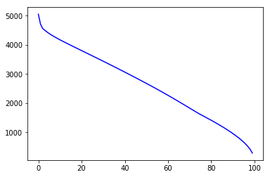

```python
plotMSE(normalized_data, 100)
```

```python
valid_set = np.loadtxt('data/joke_data/validation.txt', delimiter=',')
valid_set = valid_set.astype(int)
def validation_error(jokes, d):
    U, s, V = np.linalg.svd(jokes, full_matrices=False)
    s[d:] = 0
    S = np.zeros((100, 100))
    S[:100, :100] = np.diag(s)
    R = U @ S @ V
    R = np.where(R < 0, 0, 1)
    valid_preds = valid_set[:, 2]
    preds = R[valid_set[:, 0] - 1, valid_set[:, 1] - 1]
    diff = preds - valid_preds
    num_wrong = np.count_nonzero(diff)
    return num_wrong / len(diff)

def plot_validation_error(jokes):
    errors = []
    xs = [i for i in range(100)]
    for d in range(100):
        err = validation_error(jokes, d)
        errors.append(err)
    fig = plt.figure()
    ax = fig.add_subplot(111)
    ax.plot(xs, errors, 'b-');
```

Below, I give the validation error for $d = 2, 5, 10, 20$. I also give a plot of the error as a function of $d$. $d = 9$ gave the best accuracy.

```python
validation_error(normalized_data, 2)
```

```
0.2948509485094851
```

```python
validation_error(normalized_data, 5)
```

```
0.2845528455284553
```

```python
validation_error(normalized_data, 10)
```

```
0.2834688346883469
```

```python
validation_error(normalized_data, 20)
```

```
0.3140921409214092
```

```python
validation_error(normalized_data, 9)
```

```
0.2785907859078591
```

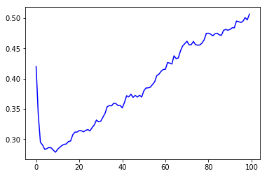

```python
plot_validation_error(normalized_data)
```

### Derivation

Define the loss function $$L(\{u_i\}, \{v_j\}) := \sum_{(i, j) \in S} (\langle u_i, v_j \rangle - R_{ij})^2 + \lambda \sum_{i=1}^n \|u_i\|_2^2 + \lambda \sum_{j=1}^m \|v_j\|_2^2$$

First we take the derivative wrt to $u_i$ to get $$\frac{\partial L}{\partial u_i} = 2 (u_i^Tv_j - R_{ij})v_j + 2 \lambda u_i$$

The equation is symmetric wrt $u$ and $v$ so we get \begin{align*} v_j^* &= \frac{R_{ij} u_i}{|u_i|_2^2 + \lambda} \end{align*}

For computational purposes, I prefer to use the stochastic gradient descent updates: $$e_{ij} = R_{ij} - u_i^Tv_j$$ giving $$v_j^{(t+1)} = v_j^{(t)} + \eta(e_{ij} u_i - \lambda v_j)$$ $$u_i^{(t+1)} = u_i^{(t)} + \eta(e_{ij} v_j - \lambda u_i)$$

```python
from sklearn import preprocessing
data = joke_data['train']
indices = np.isnan(data)
data[indices] = 0
#mms = preprocessing.MinMaxScaler(feature_range=(-1, 1))
jokes = preprocessing.normalize(data)
#jokes = mms.fit_transform(data)
```

```python
def SGD(jokes, d, eta=.0001, lda=.0001, num_epochs=1):
    # First compute R
    U, s, V = np.linalg.svd(jokes, full_matrices=False)
    s[d:] = 0
    S = np.zeros((100, 100))
    S[:100, :100] = np.diag(s)
    R = U @ S @ V
    u = U @ np.sqrt(S)
    v = np.sqrt(S) @ V
    for k in range(num_epochs):
        for j in range(jokes.shape[1]):
            for i in range(jokes.shape[0]):
                e = jokes[i, j] - (u[i, :] @ v[j, :])
                v[j, :] += eta * (e * u[i, :] - lda * v[j, :])
        for i in range(jokes.shape[0]):
            for j in range(jokes.shape[1]):
                e = jokes[i, j] - (u[i, :] @ v[j, :])
                u[i, :] += eta * (e * v[j, :] - lda * u[i, :])
    return u @ v
```

```python
r = SGD(jokes, 9, num_epochs=2)
```

```python
rp = mms.fit_transform(r)
```

```python
R = np.where(r < .5, 0, 1)
valid_preds = valid_set[:, 2]
preds = R[valid_set[:, 0] - 1, valid_set[:, 1] - 1]
diff = preds - valid_preds
num_wrong = np.count_nonzero(diff)
print(num_wrong / len(diff))
```

[output not shown]

```python
valid_set = np.loadtxt('data/joke_data/query.txt', delimiter=',')
valid_set = valid_set.astype(int)
U, s, V = np.linalg.svd(jokes, full_matrices=False)
s[4:] = 0
S = np.zeros((100, 100))
S[:100, :100] = np.diag(s)
R = U @ S @ V
R = np.where(R < .5, 0, 1)
preds = R[valid_set[:, 1] - 1, valid_set[:, 2] - 1]
ids = valid_set[:, 0]
predictions = np.hstack((ids[:, None], preds[:, None]))
print(predictions)
np.savetxt('data/joke_preds.csv', predictions, fmt='%d', delimiter=',')
```